# Bxy strain pangenome analyses

Generates all figures and tables

#### Input files

```r
#inputs annotation, gene table, Bxy metdata,all_prot
Bxydir = 'results/pangenome/Bacteroides_xylanisolvens'
indir = file.path('results/analyses_input_files')
outdir = file.path('results/output_figures_tables')
dir.create(outdir)
annotation = read_tsv(file= file.path(indir,'Bxy_roary_nosplitparalogs_annotation.txt'),
                      col_types = cols())
gene_table = read_tsv(file= file.path(indir,'Bxy_roary_nosplitparalogs_gene_table.txt'),
                      col_types = cols())
Bxy_metadata = read_tsv(file=file.path(indir,'Bxy_metadata.txt'),
                      col_types = cols())
Bxy_tree = read.tree(file = file.path(indir,'Bacteroides_xylanisolvens.tre'))
pres_abs =  read_tsv(file= file.path(indir,'roary_nosplitparalogs_gene_presence_absence.txt'),
                      col_types = cols())

#files
sulfatase_prot_file = file.path(indir,'sulfatase.faa')
OG_AAI = read_tsv(file=file.path(indir,'sulfatase_OG_AAI.txt'))
sulfa_blastp = read_tsv(file.path(indir,'sulfatase_blastp.txt'),
                      comment='#',col_names = FALSE, col_types = cols())
```

```r
Bxy_metadata %>%
  group_by(clade,captive_clade,host_site) %>%
  tally()
```

```
## # A tibble: 14 x 4
## # Groups:   clade, captive_clade [7]
##    clade      captive_clade host_site                  n
##    <chr>      <chr>         <chr>                  <int>
##  1 cladeA     gorilla1      gorilla_Columbus_Zoo       4
##  2 cladeA     mixedhost     bonobo_Columbus_Zoo        4
##  3 cladeA     mixedhost     chimpanzee_Houston_Zoo    13
##  4 cladeA     mixedhost     orangutan_Houston_Zoo      5
##  5 cladeA     unassigned    chicken_Europe             2
##  6 cladeA     unassigned    human_China                7
##  7 cladeA     unassigned    human_USA_Europe           8
##  8 cladeB     gorilla2      gorilla_Columbus_Zoo      13
##  9 cladeB     unassigned    human_China                1
## 10 cladeB     unassigned    human_USA_Europe           8
## 11 cladeC     unassigned    human_China                1
## 12 cladeC     unassigned    human_USA_Europe          59
## 13 unassigned unassigned    human_USA_Europe           7
## 14 unassigned unassigned    rumen_USA                  2
```

```r
Bxy_metadata %>%
  filter(clade != 'unassigned') %>%
  rstatix::kruskal_test(predicted.genes ~ clade)
```

```
## # A tibble: 1 x 6
##   .y.                 n statistic    df        p method
## * <chr>           <int>     <dbl> <int>    <dbl> <chr>
## 1 predicted.genes   125      46.2     2 9.42e-11 Kruskal-Wallis
```

### Kruskal-Wallis Functional groups

Identify gene function convergently enriched in strains isolated from captive apes relative to those isolated from humans in both major clades A and B

```r
#output: Kruskal-Wallis table copy number difference in function groups
print(length(unique(annotation$func_group)))
```

```
## [1] 6195
```

```r
#get gene counts for each func group for all isolates
func <- annotation %>%
  left_join(gene_table,by='Gene') %>%
  filter(!is.na(func_group)) %>%
  pivot_longer(cols=Bxy_metadata$isolate,
               names_to='isolate',values_to='present') %>%
  select(func_group,func_annot,isolate,present) %>%
  group_by(func_group,func_annot,isolate) %>%
  summarise(count = sum(present))
head(func)
```

```
## # A tibble: 6 x 4
## # Groups:   func_group, func_annot [1]
##   func_group               func_annot        isolate                       count
##   <chr>                    <chr>             <chr>                         <dbl>
## 1 1G51M@1117|Cyanobacteri… hypothetical pro… GCA.000178215.1.ASM17821v1        0
## 2 1G51M@1117|Cyanobacteri… hypothetical pro… GCA.000178295.1.ASM17829v1        0
## 3 1G51M@1117|Cyanobacteri… hypothetical pro… GCA.000210075.1.ASM21007v1        0
## 4 1G51M@1117|Cyanobacteri… hypothetical pro… GCA.000273315.1.Bact.xyla.CL…     0
## 5 1G51M@1117|Cyanobacteri… hypothetical pro… GCA.002161115.1.ASM216111v1       0
## 6 1G51M@1117|Cyanobacteri… hypothetical pro… GCA.002161135.1.ASM216113v1       0
```

```r
#add metadata
func <- Bxy_metadata %>%
  select(isolate,host,human_ape,host_site,clade,captive_clade) %>%
  left_join(func,by='isolate',fill=0)

#create new df that show mean gene count across all func groups in apes and humans
func_mean <- func %>%
  group_by(func_group,func_annot,clade,human_ape) %>%
  summarize(mean_count = mean(count)) %>%
  unite(col=host_clade,c(clade,human_ape),sep='_',remove=F)  %>%
  filter(human_ape=='human'|human_ape=='ape') %>% #subset to just captive apes and humans from clades A and B
  filter(clade!='unassigned') %>%
  unite(col=host_clade,c(clade,human_ape),sep='_',remove=T) %>%
  pivot_wider(names_from = host_clade,values_from=mean_count) %>%
  filter(cladeA_ape != cladeA_human,cladeB_ape != cladeB_human) #some difference to observe
#func groups tested with KW
nrow(func_mean)
```

```
## [1] 1400
```

```r
#subset to just captive apes and humans from clades A and B
func_humanape <- func %>%
  filter(human_ape %in% c('human','ape'),clade!='unassigned')  %>%
  unite(col=host_clade,c(clade,human_ape),sep='_',remove=F) %>%
  filter(func_group %in% func_mean$func_group)

#run kruskal wallis on functional groups
kw = func_humanape %>%
  filter(clade != 'cladeC') %>%
  group_by(func_group,func_annot,clade) %>%
  rstatix::kruskal_test(count ~ host_clade)
kw$p_fdr_adj = p.adjust(kw$p, method = 'fdr')

#add back mean gene count info to kw results
kw_mean <- kw %>%
  left_join(func_mean,by=c('func_group','func_annot')) %>%
  mutate(ape_mean = ifelse(clade == 'cladeA', cladeA_ape, cladeB_ape))%>%
  mutate(human_mean = ifelse(clade == 'cladeA', cladeA_human, cladeB_human)) %>%
  mutate(diff = ape_mean-human_mean) %>%
  select(-c(cladeA_ape, cladeB_ape,cladeA_human, cladeB_human, cladeC_human)) %>%
  select(clade, ape_mean, human_mean, diff, everything())

#identify func groups that are convergently enriched in captive apes
kw_convergent = kw_mean %>%
  filter(p_fdr_adj < .001, ape_mean > human_mean)  %>%
  add_count(func_group,name='count') %>%
  filter(count == 2)
nrow(kw_convergent)
```

```
## [1] 246
```

```r
#label func group in table
kw_mean = kw_mean %>%
  mutate(converge_captive = if_else(
    func_group %in% kw_convergent$func_group & ape_mean > human_mean, 1, 0)) %>%
  arrange(desc(converge_captive),desc(diff)) %>%
  select(func_group,func_annot,clade,ape_mean,human_mean,
         method,n,statistic,df,p,p_fdr_adj,converge_captive) %>%
  mutate(p = round(p,3),
         p_adj = round(p_fdr_adj,3))
head(kw_mean)
```

```
## # A tibble: 6 x 13
##   func_group  func_annot  clade ape_mean human_mean method     n statistic    df
##   <chr>       <chr>       <chr>    <dbl>      <dbl> <chr>  <int>     <dbl> <int>
## 1 COG3119@2|… N-acetylga… clad…    50.2        27.3 Krusk…    41      28.6     1
## 2 COG3119@2|… N-acetylga… clad…    43.2        28.2 Krusk…    22      18.1     1
## 3 COG3250@2|… Beta-galac… clad…    21.5        11.1 Krusk…    41      29.7     1
## 4 2ZA7H@2|Ba… hypothetic… clad…     5.54        0.2 Krusk…    41      29.2     1
## 5 COG4206@2|… TonB-depen… clad…    19.2        14   Krusk…    41      31.5     1
## 6 2ZA7H@2|Ba… hypothetic… clad…     4           0   Krusk…    22      21       1
## # … with 4 more variables: p <dbl>, p_fdr_adj <dbl>, converge_captive <dbl>,
## #   p_adj <dbl>
```

```r
write_tsv(kw_mean,file=file.path(outdir,'TableS3_kw_func_groups.txt'))
```

### Kruskal-Wallis Sulftase genes

Determine whether sulfatase functions within COG3119 are enriched in Bxy strains isolated from captive apes

```r
#inputs: annotation, gene table, Bxy metdata
#output: Kruskal-Wallis table copy number difference in sulfatase functions

#get gene counts for each func group for all isolates
COG3119  <- annotation %>%
  left_join(gene_table,by='Gene') %>%
  filter(str_detect(eggnog_best_OG_name,'COG3119@2')) %>%
  pivot_longer(cols=Bxy_metadata$isolate,
               names_to='isolate',values_to='present') %>%
  select(Annotation,isolate,present) %>%
  group_by(Annotation,isolate) %>%
  summarise(count = sum(present))
head(COG3119)
```

```
## # A tibble: 6 x 3
## # Groups:   Annotation [1]
##   Annotation                isolate                                 count
##   <chr>                     <chr>                                   <dbl>
## 1 Alkaline phosphatase PafA GCA.000178215.1.ASM17821v1                  1
## 2 Alkaline phosphatase PafA GCA.000178295.1.ASM17829v1                  1
## 3 Alkaline phosphatase PafA GCA.000210075.1.ASM21007v1                  1
## 4 Alkaline phosphatase PafA GCA.000273315.1.Bact.xyla.CL03T12C04.V1     1
## 5 Alkaline phosphatase PafA GCA.002161115.1.ASM216111v1                 1
## 6 Alkaline phosphatase PafA GCA.002161135.1.ASM216113v1                 1
```

```r
#add metadata
COG3119 <- Bxy_metadata %>%
  select(isolate,host,human_ape,host_site,clade,captive_clade) %>%
  left_join(COG3119,by='isolate',fill=0)

#add mean gene count across all apes and humans
COG3119_mean <- COG3119 %>%
  group_by(Annotation,clade,human_ape) %>%
  summarize(mean_count = mean(count)) %>%
  unite(col=host_clade,c(clade,human_ape),sep='_',remove=F)  %>%
  filter(human_ape=='human'|human_ape=='ape') %>% #subset to just captive apes and humans from clades A and B
  filter(clade!='unassigned') %>%
  unite(col=host_clade,c(clade,human_ape),sep='_',remove=T) %>%
  pivot_wider(names_from = host_clade,values_from=mean_count) %>%
  filter(cladeA_ape != cladeA_human,cladeB_ape != cladeB_human) #some difference to observe
head(COG3119_mean)
```

```
## # A tibble: 6 x 6
## # Groups:   Annotation [6]
##   Annotation        cladeA_ape cladeA_human cladeB_ape cladeB_human cladeC_human
##   <chr>                  <dbl>        <dbl>      <dbl>        <dbl>        <dbl>
## 1 Arylsulfatase         12.3          9           14.2        7.44          2.35
## 2 Bifunctional sul…      0.846        0.733        1          0.111         0.05
## 3 Delta 4,5-hexuro…      1.85         1.73         3          2.11          1.03
## 4 hypothetical pro…      8.92         3.6          4          4.22          2.15
## 5 N-acetylgalactos…     15.3          7.67        10          7             3.02
## 6 N-acetylglucosam…      8.35         3.2          6          4.22          1.93
```

```r
#subset to just captive apes and humans from clades A and B
COG3119_humanape <- COG3119 %>%
  filter(human_ape %in% c('human','ape'),clade!='unassigned')  %>%
  unite(col=host_clade,c(clade,human_ape),sep='_',remove=F) %>%
  filter(Annotation %in% COG3119_mean$Annotation)

#run kruskal wallis on functional groups
kw_COG3119 = COG3119_humanape  %>%
  filter(clade != 'cladeC') %>%
  group_by(Annotation,clade) %>%
  rstatix::kruskal_test(count ~ host_clade)
kw_COG3119$p_adj = p.adjust(kw_COG3119$p, method = 'fdr')

#add back mean gene count info to kw results
kw_COG3119_mean <- kw_COG3119 %>%
  left_join(COG3119_mean,by=c('Annotation')) %>%
  mutate(ape_mean = ifelse(clade == 'cladeA', cladeA_ape, cladeB_ape))%>%
  mutate(human_mean = ifelse(clade == 'cladeA', cladeA_human, cladeB_human)) %>%
  mutate(diff = ape_mean-human_mean) %>%
  select(-c(cladeA_ape, cladeB_ape,cladeA_human, cladeB_human, cladeC_human)) %>%
  select(clade, ape_mean, human_mean, everything())

#identify func groups that are convergently enriched in captive apes
kw_COG3119_convergent = kw_COG3119_mean %>%
  filter(p_adj < .001, ape_mean > human_mean)  %>%
  add_count(Annotation,name='count') %>%
  filter(count == 2)

#label func group in table
kw_COG3119_mean = kw_COG3119_mean %>%
  mutate(converge_captive = if_else(
    Annotation %in% kw_COG3119_convergent$Annotation & ape_mean > human_mean, 1, 0)) %>%
  arrange(desc(converge_captive),desc(diff)) %>%
  select(Annotation,clade,ape_mean,human_mean,method,n,statistic,df,p,p_adj,converge_captive) %>%
  mutate(p = round(p,3),
         p_adj = round(p_adj,3))
print(kw_COG3119_mean)
```

```
## # A tibble: 14 x 11
##    Annotation clade ape_mean human_mean method     n statistic    df     p p_adj
##    <chr>      <chr>    <dbl>      <dbl> <chr>  <int>     <dbl> <int> <dbl> <dbl>
##  1 Ulvan-act… clad…   15.6        6.87  Krusk…    41    28.4       1 0     0
##  2 N-acetylg… clad…   15.3        7.67  Krusk…    41    30.4       1 0     0
##  3 Arylsulfa… clad…   14.2        7.44  Krusk…    22    18.4       1 0     0
##  4 Ulvan-act… clad…   14          8.22  Krusk…    22    20.4       1 0     0
##  5 N-acetylg… clad…    8.35       3.2   Krusk…    41    29.8       1 0     0
##  6 Arylsulfa… clad…   12.3        9     Krusk…    41    17.9       1 0     0
##  7 N-acetylg… clad…   10          7     Krusk…    22    20.0       1 0     0
##  8 N-acetylg… clad…    6          4.22  Krusk…    22    17.3       1 0     0
##  9 hypotheti… clad…    8.92       3.6   Krusk…    41    23.8       1 0     0
## 10 Bifunctio… clad…    1          0.111 Krusk…    22    17.3       1 0     0
## 11 Delta 4,5… clad…    3          2.11  Krusk…    22    17.3       1 0     0
## 12 Bifunctio… clad…    0.846      0.733 Krusk…    41     0.757     1 0.384 0.386
## 13 Delta 4,5… clad…    1.85       1.73  Krusk…    41     0.752     1 0.386 0.386
## 14 hypotheti… clad…    4          4.22  Krusk…    22     1.44      1 0.229 0.267
## # … with 1 more variable: converge_captive <dbl>
```

```r
write_tsv(kw_COG3119_mean,file=file.path(outdir,'TableS4_kw_sulfatase_annotation.txt'))
```

### Figure 1

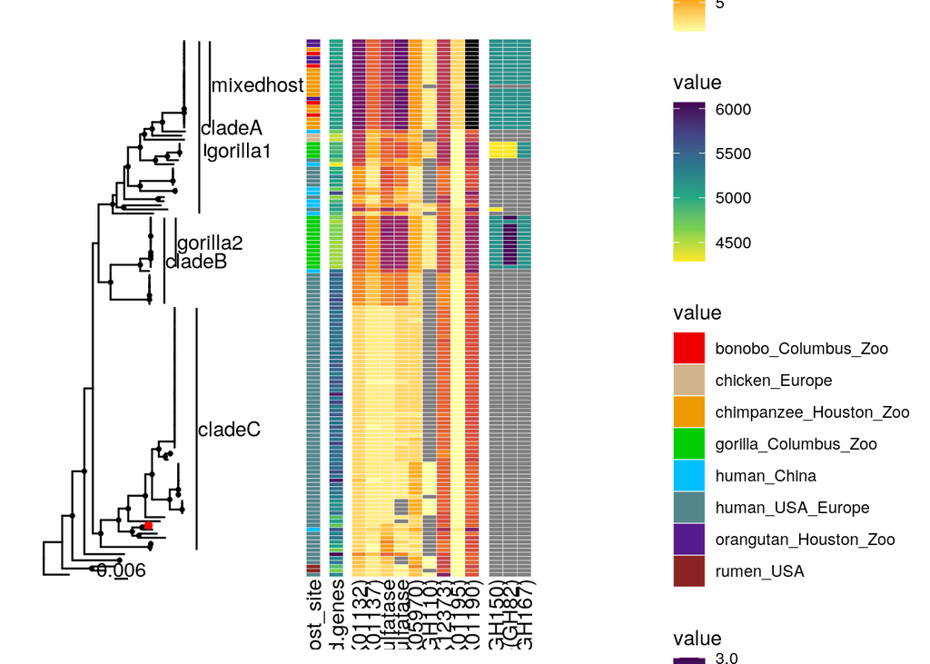

```r
#inputs: annotation,gene table
get_func_copynumber_table <- function(list_of_func){
  #given list of function groups returns table with gene copy numbers for each isolate
  func_copynumber_table  <- annotation %>%
    left_join(gene_table,by='Gene') %>%
    filter(func_group %in% list_of_func) %>%
    pivot_longer(cols=Bxy_metadata$isolate,
               names_to='isolate',values_to='present') %>%
    select(func_group,isolate,present) %>%
    group_by(func_group,isolate) %>%
    summarise(count = sum(present)) %>%
    pivot_wider(names_from = func_group, values_from = count) %>%
    column_to_rownames(var='isolate')
    func_copynumber_table[func_copynumber_table==0] <- NA
  return(func_copynumber_table)
}

mucin <- get_func_copynumber_table(c('COG3119@2|Bacteria_K01136_NA',
                                     'COG3119@2|Bacteria_K01565_NA',
                                     'COG1649@2|Bacteria_K05970_NA',
                                     'COG5434@2|Bacteria_NA_GH110' ,
                                     'COG3525@2|Bacteria_K12373_GH20',
                                     'COG3250@2|Bacteria_K01195_GH2',
                                     'COG3250@2|Bacteria_K01190_GH2'
                                   ))

mucin <- mucin %>% as.data.frame() %>%
                                    dplyr::rename('iduronate 2-sulfatase(K01136)'='COG3119@2|Bacteria_K01136_NA',
                                           'N-sulfoglucosamine sulfohydrolase(K01565)'='COG3119@2|Bacteria_K01565_NA',
                                           'sialate O-acetylesterase(K05970)'='COG1649@2|Bacteria_K05970_NA',
                                           'alpha-1,3-galactosidase(GH110)'='COG5434@2|Bacteria_NA_GH110',
                                           'hexosaminidase(K12373)'='COG3525@2|Bacteria_K12373_GH20',
                                           'beta-glucuronidase(K01195)'='COG3250@2|Bacteria_K01195_GH2',
                                           'beta-galactosidase(K01190)'='COG3250@2|Bacteria_K01190_GH2')

carrageenen <- get_func_copynumber_table(c('COG1874@2|Bacteria_NA_GH167','NA_NA_GH167',
                                           '33PQM@2|Bacteria_NA_GH150','COG5434@2|Bacteria_NA_GH82'))
carrageenen <- carrageenen %>% as.data.frame() %>%
                                        dplyr::rename('Lambda-carrageenase(GH150)'='33PQM@2|Bacteria_NA_GH150',
                                               'Iota-carrageenase(GH82)'='COG5434@2|Bacteria_NA_GH82',
                                               'GH167a'='COG1874@2|Bacteria_NA_GH167',
                                               'GH167b'='NA_NA_GH167') %>%
                                        mutate(beta_carrageenase=GH167a+GH167b) %>%
                                        dplyr::rename('beta_carrageenase(GH167)'='beta_carrageenase') %>%
                                        select(-GH167a,-GH167b)

get_annot_copynumber_table <- function(list_of_annot){
  #given list of function groups returns table with gene copy numbers for each isolate
  annot_copynumber_table  <- annotation %>%
    left_join(gene_table,by='Gene') %>%
    filter(Annotation %in% list_of_annot) %>%
    pivot_longer(cols=Bxy_metadata$isolate,
               names_to='isolate',values_to='present') %>%
    select(Annotation,isolate,present) %>%
    group_by(Annotation,isolate) %>%
    summarise(count = sum(present)) %>%
    pivot_wider(names_from = Annotation, values_from = count) %>%
    column_to_rownames(var='isolate')
    annot_copynumber_table[annot_copynumber_table==0] <- NA
  return(annot_copynumber_table)
}
sulfatase = get_annot_copynumber_table(c('N-acetylgalactosamine-6-O-sulfatase',
                                         'N-acetylglucosamine-6-O-sulfatase',
                                         'Ulvan-active sulfatase','Arylsulfatase'))
sulfatase = sulfatase %>% as.data.frame() %>%
                  dplyr::rename('N-acetylgalactosamine-6-O-sulfatase(K01132)'='N-acetylgalactosamine-6-O-sulfatase',
                         'N-acetylglucosamine-6-O-sulfatase(K01137)'='N-acetylglucosamine-6-O-sulfatase'
                         )
sulfa_mucin = cbind(sulfatase,mucin)
sulfa_mucin = sulfa_mucin[c("N-acetylgalactosamine-6-O-sulfatase(K01132)",
              "N-acetylglucosamine-6-O-sulfatase(K01137)",
              'Arylsulfatase',
              'Ulvan-active sulfatase',
              "sialate O-acetylesterase(K05970)",
              "alpha-1,3-galactosidase(GH110)",
              "hexosaminidase(K12373)",
              "beta-glucuronidase(K01195)",
              "beta-galactosidase(K01190)")]
HOST_table <- Bxy_metadata %>%
  select(isolate,host_site) %>%
  column_to_rownames(var='isolate')

predicted.genes = Bxy_metadata %>% select(isolate,predicted.genes) %>%
  mutate(predicted.genes=as.numeric(predicted.genes)) %>%
  column_to_rownames(var='isolate')

#format tree
outgroup_names <- Bxy_metadata %>%
  filter(taxonomy_Species!='Bacteroides_xylanisolvens') %>%
  pull(isolate)
Bxy_tree <- drop.tip(Bxy_tree,outgroup_names)
tree_v1 = ggtree(Bxy_tree) %<+%
  Bxy_metadata +
  geom_nodepoint(aes(subset = suppressWarnings(as.numeric(label)) > 90),size=.75) +
  geom_treescale()

cladeA_MCRA <- ape::getMRCA(Bxy_tree,Bxy_metadata$isolate[Bxy_metadata$clade=='cladeA'])
cladeB_MCRA <- ape::getMRCA(Bxy_tree,Bxy_metadata$isolate[Bxy_metadata$clade=='cladeB'])
cladeC_MCRA <- ape::getMRCA(Bxy_tree,Bxy_metadata$isolate[Bxy_metadata$clade=='cladeC'])
mixedhostNode <- ape::getMRCA(Bxy_tree,Bxy_metadata$isolate[Bxy_metadata$captive_clade=='mixedhost'])
gorilla1Node <- ape::getMRCA(Bxy_tree,Bxy_metadata$isolate[Bxy_metadata$captive_clade=='gorilla1'])
gorilla2Node <- ape::getMRCA(Bxy_tree,Bxy_metadata$isolate[Bxy_metadata$captive_clade=='gorilla2'])
tree_v2 = tree_v1 + #add clade labels
   geom_cladelabel(node=cladeA_MCRA,label="cladeA",offset = .005)+
   geom_cladelabel(node=cladeB_MCRA,label="cladeB",offset = .005)+
   geom_cladelabel(node=cladeC_MCRA,label="cladeC",offset = .005)+
   geom_cladelabel(node=mixedhostNode,label="mixedhost",offset = .01) +
   geom_cladelabel(node=gorilla1Node,label="gorilla1",offset = .01)+
   geom_cladelabel(node=gorilla2Node,label="gorilla2",offset = .01) +
   geom_tippoint(aes(subset=(label=='GCA.000210075.1.ASM21007v1')),color='red') +
   xlim(NA,.25)

get_color_palette <- function(tips) {
  Bxy_metadata <- Bxy_metadata %>% filter(isolate %in% tips)
  vec <- sort(unique(Bxy_metadata$host_site))
  return(recode(vec,
                          'human_USA_Europe'='cadetblue4',
                          'human_China' = 'deepskyblue',
                          'rumen_USA' = 'brown4',
                          'bonobo_Columbus_Zoo'='red2',
                          'chimpanzee_Houston_Zoo'='orange2',
                          'orangutan_Houston_Zoo'='purple4',
                          'gorilla_Columbus_Zoo'='green3',
                          'chicken_Europe'='tan',
                          'missing_siteUnknown'='brown4'))}

p <- gheatmap(tree_v2 + ylim(-10,NA),
    HOST_table,width=.1,colnames_angle=90,hjust=1,offset=.05)  +
    scale_fill_manual(values=get_color_palette(Bxy_tree$tip.label))
p <- p + new_scale_fill()
p1b <- gheatmap(p,predicted.genes,colnames_angle=90,hjust=1,offset=.06,width=.1) +
    scale_fill_viridis_c(direction = -1, option="D")
p1b <- p1b + new_scale_fill()
p2 <- gheatmap(p1b,sulfa_mucin,colnames_angle=90,hjust=1,offset=.07,width=.9) +
    scale_fill_viridis_c(direction = -1, option="B")
p2 <- p2 + new_scale_fill()
(p3 <- gheatmap(p2,carrageenen,colnames_angle=90,hjust=1,offset=.13,width=.3)+
    scale_fill_viridis_c(option="D",direction = -1))
```

```r
ggsave(p3,file = file.path(outdir,'Figure1_long.pdf'),width = 10, height=12)
ggsave(p3,file = file.path(outdir,'Figure1_short.pdf'),width = 10, height=6)
```

### Figure 2

Compare distribution of sulfatase genes in XB1A model to strains isolated from captive apes

```r
#filter to orthologous genes that are within the sulfatlas
sulfatase_genes <- annotation %>%
  filter(str_detect(eggnog_best_OG_name,'COG3119@2'),
         Gene != 'pafA', #Gene doesn't align well
         Gene!= 'group_4698', #Gene doesn't align well
         No..isolates > 5
         )  #remove single gene group
### make tree of sulfa genes
set.seed(131)
sulfatase_prot_file = file.path(indir,'sulfatase.faa')

###subset from all protein seqs to only sulfatase genes in captive ape strains
#all_prot file not uploaded to github showing how sulftase.faa was generated
#all_prot_file = file.path(indir,'all_prot.faa')
#all_prot = readAAStringSet(all_prot_file)
#names(all_prot) <- sapply(strsplit(names(all_prot)," "), `[`, 1)
#sulfatase_prot = all_prot[names(all_prot) %in% sulfatase_genes$Gene.ID]
#writeXStringSet(sulfatase_prot,sulfatase_prot_file)

#system(paste0('mafft --auto ',sulfatase_prot_file,' > ',sulfatase_prot_file,'.align'))
#system(paste0('fasttree ',sulfatase_prot_file,'.align > ',sulfatase_prot_file,'.tree'))

present_in_isolates <- function(list_of_genes,list_of_isolates,name) {
  #given list of genes and isolates, determine the total number of genes present in isolates
  isolate_gene_table <- annotation %>%
    left_join(gene_table,by='Gene') %>%
    filter(Gene %in% list_of_genes) %>%
    select(Gene,list_of_isolates) %>%
    mutate(total = rowSums(select_(., "-Gene"))) %>%
    select(Gene,total)

  isolate_gene_table = isolate_gene_table %>%
         mutate(binary = ifelse(total>0,name,NA)) %>%
         column_to_rownames('Gene')
  colnames(isolate_gene_table) <-c(paste0(name,'_total'),name)
  return(isolate_gene_table)
}

#determine which of the sulfatase_genes are present in XBA1 and captive ape lineages
mixedhost_cladeA =  Bxy_metadata %>% filter(captive_clade=='mixedhost') %>% pull(isolate)
mixedhost_cladeA = present_in_isolates(sulfatase_genes$Gene,mixedhost_cladeA,'mixedhost_cladeA')
gorilla1_cladeA =  Bxy_metadata %>% filter(captive_clade=='gorilla1') %>% pull(isolate)
gorilla1_cladeA = present_in_isolates(sulfatase_genes$Gene,gorilla1_cladeA,'gorilla1_cladeA')
gorilla2_cladeB =  Bxy_metadata %>% filter(captive_clade=='gorilla2') %>% pull(isolate)
gorilla2_cladeB = present_in_isolates(sulfatase_genes$Gene,gorilla2_cladeB,'gorilla2_cladeB')
human_cladeA =  Bxy_metadata %>% filter(clade=='cladeA',host=='human') %>% pull(isolate)
human_cladeA = present_in_isolates(sulfatase_genes$Gene,human_cladeA,'human_cladeA')
human_cladeB =  Bxy_metadata %>% filter(clade=='cladeB',host=='human') %>% pull(isolate)
human_cladeB = present_in_isolates(sulfatase_genes$Gene,human_cladeB,'human_cladeB')
human_cladeC =  Bxy_metadata %>% filter(clade=='cladeC',host=='human') %>% pull(isolate)
human_cladeC = present_in_isolates(sulfatase_genes$Gene,human_cladeC,'human_cladeC')

pres <- cbind(mixedhost_cladeA,gorilla1_cladeA,gorilla2_cladeB,human_cladeA,human_cladeB,human_cladeC)
pres = pres %>% select(!contains('total'))
#remove sulfastase group only present in outgroup Bxy strains
pres = pres[rowSums(is.na(pres)) != ncol(pres), ]
#total number of sulfatase groups
nrow(pres)
```

```
## [1] 91
```

```r
#total number of sulfatase groups
core = pres[rowSums(!is.na(pres)) == ncol(pres), ]
nrow(core)
```

```
## [1] 14
```

```r
#captive only number of sulfatase groups
captive_only = pres %>% filter(is.na(human_cladeC),is.na(human_cladeB),is.na(human_cladeA))
captive_only %>% group_by_all() %>% tally()
```

```
## # A tibble: 2 x 7
## # Groups:   mixedhost_cladeA, gorilla1_cladeA, gorilla2_cladeB, human_cladeA,
## #   human_cladeB [2]
##   mixedhost_cladeA gorilla1_cladeA gorilla2_cladeB human_cladeA human_cladeB
##   <chr>            <chr>           <chr>           <chr>        <chr>
## 1 mixedhost_cladeA gorilla1_cladeA gorilla2_cladeB <NA>         <NA>
## 2 mixedhost_cladeA <NA>            gorilla2_cladeB <NA>         <NA>
## # … with 2 more variables: human_cladeC <chr>, n <int>
```

```r
#human only number of sulfatase groups
human_only = pres %>% filter(is.na(mixedhost_cladeA),is.na(gorilla1_cladeA),is.na(gorilla2_cladeB))
human_only %>% group_by_all() %>% tally()
```

```
## # A tibble: 2 x 7
## # Groups:   mixedhost_cladeA, gorilla1_cladeA, gorilla2_cladeB, human_cladeA,
## #   human_cladeB [2]
##   mixedhost_cladeA gorilla1_cladeA gorilla2_cladeB human_cladeA human_cladeB
##   <chr>            <chr>           <chr>           <chr>        <chr>
## 1 <NA>             <NA>            <NA>            human_cladeA <NA>
## 2 <NA>             <NA>            <NA>            <NA>         <NA>
## # … with 2 more variables: human_cladeC <chr>, n <int>
```

```r
#mixedhost_cladeA number of sulfatase groups
pres %>% filter(!is.na(mixedhost_cladeA)) %>% nrow()
```

```
## [1] 68
```

```r
#gorilla1_cladeA number of sulfatase groups
pres %>% filter(!is.na(gorilla1_cladeA)) %>% nrow()
```

```
## [1] 38
```

```r
#gorilla2_cladeB number of sulfatase groups
pres %>% filter(!is.na(gorilla2_cladeB)) %>% nrow()
```

```
## [1] 51
```

```r
#human_cladeA number of sulfatase groups
pres %>% filter(!is.na(human_cladeA)) %>% nrow()
```

```
## [1] 77
```

```r
#human_cladeB number of sulfatase groups
pres %>% filter(!is.na(human_cladeB)) %>% nrow()
```

```
## [1] 38
```

```r
#human_cladeC number of sulfatase groups
pres %>% filter(!is.na(human_cladeC)) %>% nrow()
```

```
## [1] 23
```

```r
sulfadata  <- pres %>%
  rownames_to_column(var='Gene')%>%
  left_join(annotation,by='Gene')

#reorder pres abs table
pres = pres[c('human_cladeC','human_cladeB','gorilla2_cladeB',
              'human_cladeA','mixedhost_cladeA','gorilla1_cladeA')]

#label tree tips with sulfatase gene ortholog
sulfa_tree <- read.tree(paste0(sulfatase_prot_file,'.tree')) #read in tree
get_group <- function(prot){sulfadata$Gene[sulfadata$Gene.ID == prot]}
sulfa_tree$tip.label <- as.character(lapply(sulfa_tree$tip.label,get_group))
sulfa_tree <- keep.tip(sulfa_tree,rownames(pres)) #remove tips not in dataframe

#format table for display with ggtree
#annotated function
func <- sulfadata %>%
  dplyr::select(Gene,Annotation) %>%
  column_to_rownames(var='Gene') %>% as.matrix()
#sulfatase subfamily
subfamily <- sulfadata %>%
  dplyr::select(Gene,sulfatlas_subfamily) %>%
  filter(Gene %in% sulfa_tree$tip.label) %>%
  mutate(sulfatase_subfamily = as.character(sulfatlas_subfamily)) %>%
  column_to_rownames(var='Gene') %>% as.matrix()
colourCount = length(unique(subfamily[,'sulfatlas_subfamily'])) #increase color palette
subfamily_pal = colorRampPalette(brewer.pal(colourCount, "Paired"))(colourCount)

#identify sulfatase genes only present in captive ape clades
coregenes = rownames(pres)[rowSums(!is.na(pres)) == ncol(pres)]

#build sulfatase tree
sulfa_tree_gg = ggtree(sulfa_tree,layout='circular') +
  geom_point2(aes(subset=(label%in%coregenes)),
              shape=21, size=1, fill='black') +
  geom_treescale()

#determine internal tree nodes for sulfatase subfamilies
got_subfam_node <- function(sub){
  subfam = sulfadata$Gene[sulfadata$sulfatlas_subfamily==sub]
  subfam = intersect(subfam,sulfa_tree$tip.label)
  subfam_node = getMRCA(sulfa_tree,subfam)
  return(subfam_node)
}
#got_subfam_node(15)

#number of orthologous gene groups per sulfatase subfamily
table(sulfadata$sulfatlas_subfamily)
```

```
##
##  4  7  8  9 11 14 15 16 19 20 22 24 25 27 28 30 31 46 50 53 55 62 67
##  7  3 12  2  2  3  6  3  1  3  2  1  1  2  2  3  1  1  1  1  1  1  2
```

```r
nodes = lapply(unique(sulfadata$sulfatlas_subfamily),got_subfam_node)
names(nodes) = unique(sulfadata$sulfatlas_subfamily)
unlist(nodes) #subfamily & node
```

```
##  15  27   9  20  11  67   4  14   8  22   7  16  30  28
## 153 114 108 149 118 105 143 133 163 160  97 138 112 180
```

```r
#singleton subfamilies with 1 rep
singleton_S1 = names(table(sulfadata$sulfatlas_subfamily))[table(sulfadata$sulfatlas_subfamily)==1]
singleton_S1 = sulfadata %>% filter(sulfatlas_subfamily %in% singleton_S1)
#groups with unassigned subfamilies
unassigned_S1 = sulfadata %>% filter(is.na(sulfatlas_subfamily))
nrow(unassigned_S1)
```

```
## [1] 30
```

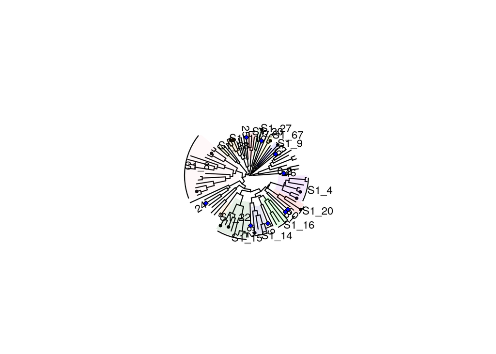

```r
#unassigned_S1_prot = all_prot[names(all_prot) %in% unassigned_S1$Gene.ID]
#unassigned_S1_prot_file = file.path(indir,'sulfatase_S1_unassigned.faa')
#writeXStringSet(unassigned_S1_prot,unassigned_S1_prot_file)

#add sulfatase subfamilies to tree
sulfa_tree_gg_v2 = sulfa_tree_gg +
  geom_hilight(node=153, fill="darkgreen", alpha=.1) +
  geom_cladelabel(node=153,label="S1_15") +
  geom_hilight(node=114, fill="darkgreen", alpha=.1) +
  geom_cladelabel(node=114,label="S1_27") +
  geom_hilight(node=108, fill="blue", alpha=.1) +
  geom_cladelabel(node=108,label="S1_9") +
  geom_hilight(node=149, fill="red", alpha=.1) +
  geom_cladelabel(node=149,label="S1_20") +
  geom_hilight(node=118, fill="orange", alpha=.1) +
  geom_cladelabel(node=118,label="S1_11") +
  geom_hilight(node=105, fill="yellow", alpha=.1) +
  geom_cladelabel(node=105,label="S1_67") +
  geom_hilight(node=143, fill="purple", alpha=.1) +
  geom_cladelabel(node=143,label="S1_4") +
  geom_hilight(node=133, fill="blue4", alpha=.1) +
  geom_cladelabel(node=133,label="S1_14") +
  geom_hilight(node=163, fill="pink", alpha=.1) +
  geom_cladelabel(node=163,label="S1_8") +
  geom_hilight(node=160, fill="darkorange", alpha=.1) +
  geom_cladelabel(node=160,label="S1_22") +
  geom_hilight(node=138, fill="green", alpha=.1) +
  geom_cladelabel(node=138,label="S1_16") +
  geom_hilight(node=112, fill="red2", alpha=.1) +
  geom_cladelabel(node=112,label="S1_30") +
  geom_hilight(node=180, fill="yellow4", alpha=.1) +
  geom_cladelabel(node=180,label="S1_28") +
  geom_treescale()

sulfa_tree_gg_v3 = sulfa_tree_gg_v2 %<+% sulfadata + xlim(NA, 5) +
    geom_tiplab(aes(label=sulfatlas_subfamily, subset=(label%in%singleton_S1$Gene)), parse=T) +
    geom_tippoint(aes(label=sulfatlas_subfamily, subset=(label%in%singleton_S1$Gene)),fill = 'blue',shape=23,parse=T)
sulfa_tree_gg_v3
```

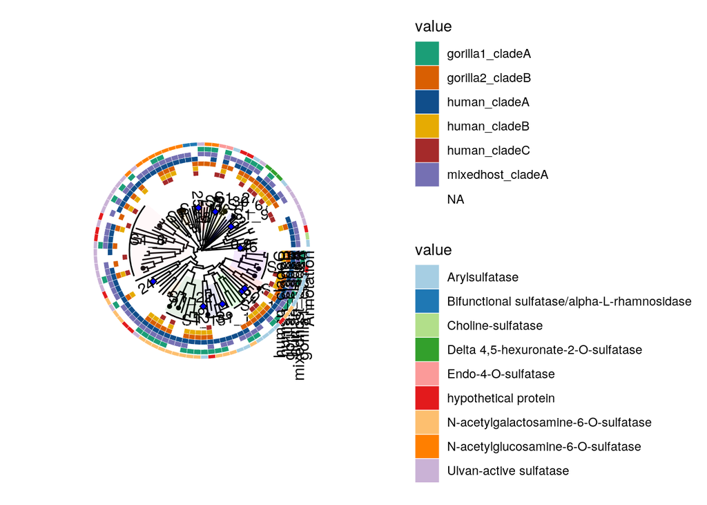

```r
color_vec <- recode(sort(colnames(pres)),
      "gorilla1_cladeA"="#1B9E77", #darkgreen
      "mixedhost_cladeA"="#7570B3", #purple
      "gorilla2_cladeB" = "#D95F02", #orange
      "human_cladeA" = 'dodgerblue4',
      "human_cladeB"= "#E6AB02",
      "human_cladeC"='brown')

p <- gheatmap(sulfa_tree_gg_v3,pres,colnames_angle=90,hjust=1,width=.4)  +
  scale_fill_manual(values=color_vec)
p <- p + new_scale_fill()
(p2 <- gheatmap(p,func,colnames_angle=90,hjust=1,offset=1,width=.05) +
    scale_fill_manual(values = brewer.pal(15, "Paired")))
```

```r
ggsave(p2,file=file.path(outdir,'Figure2_sulfatase_circle.pdf'),height=12,width=10)
```

#### Determine AAI within orthologous genes

Shows leg work behind how AAI is calculated, requires all_prot.faa generated from processing_pangenome final table with AAI among sulfatase genes is uploaded

```r
AAI_outdir = file.path(Bxydir,'gene_AAI')
dir.create(AAI_outdir)

get_ave_AAI <- function(gene){
  #given a orthologous gene extracts faa of all seqs, performs alignment,
  #writes matrix of AAI among seqs
  GeneIDs <- pres_abs %>% filter(Gene==gene) %>% select(Bxy_metadata$isolate) %>% as.character()
  GeneIDs <- unlist(strsplit(GeneIDs, "[\t]"))
  GeneIDs = GeneIDs[!is.na(GeneIDs)]
  GeneID_seqs = all_prot[names(all_prot) %in% GeneIDs]
  print(paste(gene,length(GeneID_seqs)))
  if (length(GeneID_seqs)>1){
    file = file.path(AAI_outdir,paste0(gene,'.faa'))
    writeXStringSet(GeneID_seqs,file)
    system(paste0('mafft --auto ',file,' > ',file,'.align'))
    prot_align = read.alignment(file=paste0(file,'.align'),format='fasta')
    dist = dist.alignment(prot_align,"identity")
    dist = as.matrix(dist)
    dist[lower.tri(dist,diag = TRUE)] <- NA
    dist = 1-dist
    dist_file = file.path(AAI_outdir,paste0(gene,'_dist.txt'))
    write_tsv(as.data.frame(dist),file=dist_file)
    ave_AAI = mean(dist,na.rm=TRUE)*100
    return(c(gene,ave_AAI))}
  else {
    return(NA)}}
#get_ave_AAI(gene = "group_683")

get_AAI_from_dist <- function(gene){
   #given gene reads dist matrix and
   #return average amino acid identity
   dist_file = file.path(AAI_outdir,paste0(gene,'_dist.txt'))
   dist = as.matrix(read_tsv(file=dist_file),col_types=cols())
   ave_AAI = mean(dist,na.rm=TRUE)*100
   return(data.frame(gene,ave_AAI))
}
#get_AAI_from_dist(gene = "group_683")


#completed = list.files(AAI_outdir,pattern = '_dist.txt')
#completed = unique(sapply(str_split(completed,'_dist'), `[`, 1))
#sulfatase_to_do = setdiff(sulfatase_genes$Gene,completed)
#mclapply(sulfatase_to_do,get_ave_AAI,mc.cores=20)
#sulfatase_OG_AAI = lapply(sulfatase_genes$Gene,get_AAI_from_dist) %>% bind_rows()
#write_tsv(sulfatase_OG_AAI,file=file.path(indir,'sulfatase_OG_AAI.txt'))

sulfatase_OG_AAI = read_tsv(file=file.path(indir,'sulfatase_OG_AAI.txt'))
#summary(sulfatase_OG_AAI$ave_AAI)
```

#### blastp of sulfatase genes to sulfatlas

requires download of sulfatlas as show in processing_pangenome, blastp results uploads

```bash
#blastp -query results/analyses_input_files/sulfatase.faa -db results/pangenome/Bacteroides_xylanisolvens/sulfatlas/sulfatlas_v1.3.faa -qcov_hsp_perc 80 -outfmt "6 qseqid sseqid salltitles pident evalue" -out results/analyses_input_files/sulfatase_blastp.txt
```

```r
#read in blast results
sulfa_blastp = read_tsv(file.path(indir,'sulfatase_blastp.txt'),
                      comment='#',col_names = FALSE, col_types = cols())

colnames(sulfa_blastp) <- c('Gene.ID', 'sseqid','salltitles', 'pident', 'evalue_sulfa')
sulfa_blastp <- sulfa_blastp %>%
  #mutate(Gene.ID=str_sub(Gene.ID, end=-3)) %>%
  filter(pident > 85) %>%
  separate(col = 'salltitles',into=c(NA,'id','full_descripton'),extra='drop',sep='[|]') %>%
  separate(col='id',into=c('lcl','sulfatase_family','sulfatase_subfamily'),sep='_') %>%
  separate(col='full_descripton',into=c('description','species'),sep='OS=') %>%
  separate(col='description',into=c('front','description'),sep='BACE |BACOV |BACO1 |_BACSE ')  %>%
  separate(col='species',into=c('species',NA),sep='OX=') %>%
  separate(col='species',into=c('Genus','species'),sep=' ') %>%
  mutate(Genus_sp = paste(Genus,species,sep='_')) %>%
  select('Gene.ID', 'sseqid','pident', 'evalue_sulfa',
                  'sulfatase_family','sulfatase_subfamily','description','Genus_sp')

#get best blastp for each Bacteroides species
sulfa_blastp <- sulfa_blastp %>%
  select(Gene.ID,Genus_sp,pident) %>%
  distinct() %>%
  group_by(Gene.ID,Genus_sp) %>%
     slice_max(order_by=pident,n = 1) %>%
     as.data.frame() %>%
  pivot_wider(names_from=Genus_sp,values_from=pident,values_fill=NA)
head(sulfa_blastp)
```

```
## # A tibble: 6 x 32
##   Gene.ID   Bacteroides_ovat… Bacteroides_sp. Bacteroides_acid… Bacteroides_cac…
##   <chr>                 <dbl>           <dbl>             <dbl>            <dbl>
## 1 AAFILABK…             100               100              NA               NA
## 2 AAFILABK…             100                NA              NA               NA
## 3 AAFILABK…              99.4              NA              NA               NA
## 4 AAFILABK…              98.4              NA              NA               NA
## 5 AAFILABK…              89.8              NA              NA               NA
## 6 BALBAENG…             100               100              92.5             92.7
## # … with 27 more variables: Bacteroides_xylanisolvens <dbl>,
## #   Bacteroides_thetaiotaomicron <dbl>, Bacteroides_finegoldii <dbl>,
## #   Bacteroides_caecimuris <dbl>, Bacteroides_faecichinchillae <dbl>,
## #   Bacteroides_faecis <dbl>, uncultured_Bacteroides <dbl>,
## #   Bacteroides_nordii <dbl>, Bacteroides_pyogenes <dbl>,
## #   Bacteroides_salyersiae <dbl>, gut_metagenome <dbl>,
## #   Parabacteroides_merdae <dbl>, Bacteroides_cellulosilyticus <dbl>,
## #   Bacteroides_dorei <dbl>, Bacteroides_fragilis <dbl>,
## #   Bacteroides_intestinalis <dbl>, Bacteroides_oleiciplenus <dbl>,
## #   Bacteroides_plebeius <dbl>, Bacteroides_stercorirosoris <dbl>,
## #   Bacteroides_vulgatus <dbl>, Phocaeicola_vulgatus <dbl>,
## #   Bacteroides_clarus <dbl>, Bacteroides_eggerthii <dbl>,
## #   Bacteroides_helcogenes <dbl>, Bacteroides_reticulotermitis <dbl>,
## #   Bacteroides_stercoris <dbl>, Bacteroides_uniformis <dbl>
```

```r
#combine with AAI results
table_sulfadata_captive = sulfadata %>%
  select(Gene,Gene.ID,Annotation,sulfatlas_subfamily,mixedhost_cladeA,gorilla1_cladeA,gorilla2_cladeB,human_cladeA,human_cladeB,human_cladeC)  %>%
  left_join(sulfatase_OG_AAI,by=c('Gene'='gene')) %>%
  left_join(sulfa_blastp,by=c('Gene.ID')) %>%
  select(Gene:ave_AAI,Bacteroides_xylanisolvens,Bacteroides_ovatus,Bacteroides_thetaiotaomicron,
         Bacteroides_finegoldii,Bacteroides_caecimuris,Bacteroides_faecis,
         gut_metagenome,Parabacteroides_merdae,everything())

#get max pident for other Bacteroides species
Bt_sp = table_sulfadata_captive %>%
  select(Bacteroides_sp.:Bacteroides_uniformis) %>%
  replace(is.na(.), 0)  %>%
  mutate_all(as.numeric) %>%
  rowwise() %>%
  summarize(max = max(c_across(),na.rm=T)) %>%
  pull(max)

table_sulfadata_captive = table_sulfadata_captive %>%
  select(Gene:ave_AAI,Bacteroides_xylanisolvens,Bacteroides_ovatus,Bacteroides_thetaiotaomicron,
         Bacteroides_finegoldii,Bacteroides_caecimuris,Bacteroides_faecis,
         gut_metagenome,Parabacteroides_merdae)
table_sulfadata_captive$Bt_sp = Bt_sp
write_tsv(table_sulfadata_captive,file.path(outdir,'TableS5_sulfatase_blastp.txt'))
head(table_sulfadata_captive)
```

```
##         Gene        Gene.ID                          Annotation
## 1 group_1490 KENJADKH_01220 N-acetylgalactosamine-6-O-sulfatase
## 2 group_5562 KENJADKH_04792                  Endo-4-O-sulfatase
## 3 group_2339 KENJADKH_02809  Delta 4,5-hexuronate-2-O-sulfatase
## 4     atsA_2 KENJADKH_00964 N-acetylgalactosamine-6-O-sulfatase
## 5  group_683 KENJADKH_00378 N-acetylgalactosamine-6-O-sulfatase
## 6 group_1598 KENJADKH_02788   N-acetylglucosamine-6-O-sulfatase
##   sulfatlas_subfamily mixedhost_cladeA gorilla1_cladeA gorilla2_cladeB
## 1                  15 mixedhost_cladeA gorilla1_cladeA gorilla2_cladeB
## 2                  27 mixedhost_cladeA gorilla1_cladeA gorilla2_cladeB
## 3                   9 mixedhost_cladeA gorilla1_cladeA gorilla2_cladeB
## 4                  20 mixedhost_cladeA gorilla1_cladeA gorilla2_cladeB
## 5                  15 mixedhost_cladeA gorilla1_cladeA gorilla2_cladeB
## 6                  11 mixedhost_cladeA gorilla1_cladeA gorilla2_cladeB
##   human_cladeA human_cladeB human_cladeC  ave_AAI Bacteroides_xylanisolvens
```

[output cut: 27 more lines]

### Figure 3

```r
#generate table genes distributed across captive ape clades
captive_clade_table <- gene_table %>%
  pivot_longer(cols=Bxy_metadata$isolate,
               names_to='isolate',values_to='present') %>%
  filter(present>0) %>%
  left_join(select(Bxy_metadata,isolate,host,human_ape,captive_clade),by='isolate') %>%
  group_by(Gene,captive_clade) %>%
  tally() %>%
  pivot_wider(names_from=captive_clade,values_from=n,values_fill=0)
head(captive_clade_table)
```

```
## # A tibble: 6 x 5
## # Groups:   Gene [6]
##   Gene  unassigned gorilla1 gorilla2 mixedhost
##   <chr>      <int>    <int>    <int>     <int>
## 1 aadK          37        0        0         0
## 2 aaeB           1        0        0         0
## 3 abf2          93        4       13        22
## 4 abgT          93        4       13        22
## 5 abnA          47        0        0         0
## 6 accA           1        0        0         0
```

```r
#identify ≈ as genes present in 2 or 3 clades and fewer than 3 humans
captive_clade_table <- captive_clade_table %>%
  mutate(mixedhost = as.numeric(mixedhost),
         gorilla1 = as.numeric(gorilla1),
         gorilla2 = as.numeric(gorilla2),
         cladecount = sum(if_else(mixedhost>0 & (mixedhost>.5*max(captive_clade_table$mixedhost)),1,0),
                          if_else(gorilla1>0 & (gorilla1>.5*max(captive_clade_table$gorilla1)),1,0),
                          if_else(gorilla2>0 & (gorilla2>.5*max(captive_clade_table$gorilla2)),1,0))) %>%
  filter(unassigned<3,cladecount>1)

#subset gene table to captive_convergent_genes
captive_convergent_genes <- captive_clade_table$Gene
print(length(captive_clade_table$Gene))
```

```
## [1] 178
```

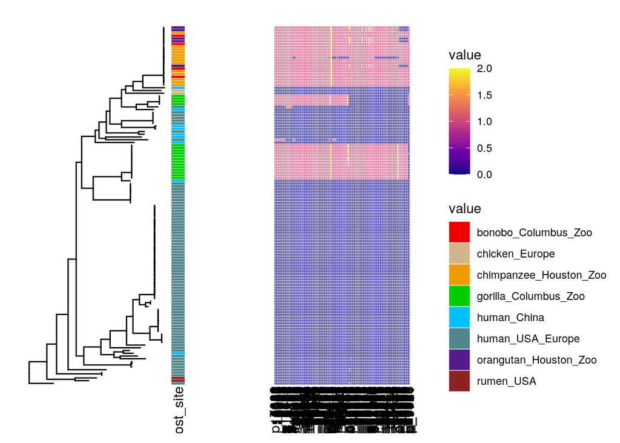

```r
captive_gene_table <- gene_table %>%
  filter(Gene %in% captive_convergent_genes) %>%
  column_to_rownames(var='Gene') %>%
  t()

saveRDS(captive_convergent_genes,file=file.path(indir,'captive_convergent_genes.RDS'))
#generate host table
HOST_table <- Bxy_metadata %>%
  dplyr::select(isolate,host_site) %>%
  column_to_rownames(var='isolate')

get_color_palette <- function(tips) {
  Bxy_metadata <- Bxy_metadata %>% filter(isolate %in% tips)
  vec <- sort(unique(Bxy_metadata$host_site))
  return(recode(vec,
                          'human_USA_Europe'='cadetblue4',
                          'human_China' = 'deepskyblue',
                          'rumen_USA' = 'brown4',
                          'bonobo_Columbus_Zoo'='red2',
                          'chimpanzee_Houston_Zoo'='orange2',
                          'orangutan_Houston_Zoo'='purple4',
                          'gorilla_Columbus_Zoo'='green3',
                          'chicken_Europe'='tan',
                          'missing_siteUnknown'='brown4'))}
#visualize genes
p <- gheatmap(ggtree(Bxy_tree) + ylim(-10,NA),
              HOST_table,width=.1,colnames_angle=90,hjust=1)  +
              scale_fill_manual(values=get_color_palette(Bxy_tree$tip.label))
p <- p + new_scale_fill()
(p2 <- gheatmap(p,captive_gene_table,offset=.05,colnames_angle=90,hjust=1) +
                scale_fill_viridis_c(option="C"))
```

#### See script Figure3_output_fna

### Figure 4

```r
list.files(file.path(indir,'pairwise_gene_islands'))
```

```
## [1] "Bacteroides_fragilis_events.txt"
## [2] "Bacteroides_fragilis_summary.txt"
## [3] "Bacteroides_ovatus_events.txt"
## [4] "Bacteroides_ovatus_summary.txt"
## [5] "Bacteroides_thetaiotaomicron_events.txt"
## [6] "Bacteroides_thetaiotaomicron_summary.txt"
## [7] "Bacteroides_xylanisolvens_events.txt"
## [8] "Bacteroides_xylanisolvens_summary.txt"
```

```r
Bxy = read_tsv(
  file.path(indir,'pairwise_gene_islands','Bacteroides_xylanisolvens_summary.txt'),
  col_types = cols())
Bov = read_tsv(
  file.path(indir,'pairwise_gene_islands','Bacteroides_ovatus_summary.txt'),
  col_types = cols())
Bfr = read_tsv(
  file.path(indir,'pairwise_gene_islands','Bacteroides_fragilis_summary.txt'),
  col_types = cols())
Bth = read_tsv(
  file.path(indir,'pairwise_gene_islands','Bacteroides_thetaiotaomicron_summary.txt'),
  col_types = cols())
colnames(Bxy)
```

```
##  [1] "iso1"                      "iso2"
##  [3] "tree_dist"                 "comp"
##  [5] "host.iso1"                 "sample.iso1"
##  [7] "taxonomy_Species.iso1"     "host.iso2"
##  [9] "sample.iso2"               "taxonomy_Species.iso2"
## [11] "window_size"               "genenum_iso1"
## [13] "genenum_iso2"              "n_gene_diff_bray"
## [15] "n_gene_diff_sorenson"      "dist_bray"
## [17] "dist_sorenson"             "n_events_bray"
## [19] "n_events_sorenson"         "mean_size_events_bray"
## [21] "mean_size_events_sorenson" "mean_treedist"
## [23] "sd_treedist"               "tree_dist_norm"
```

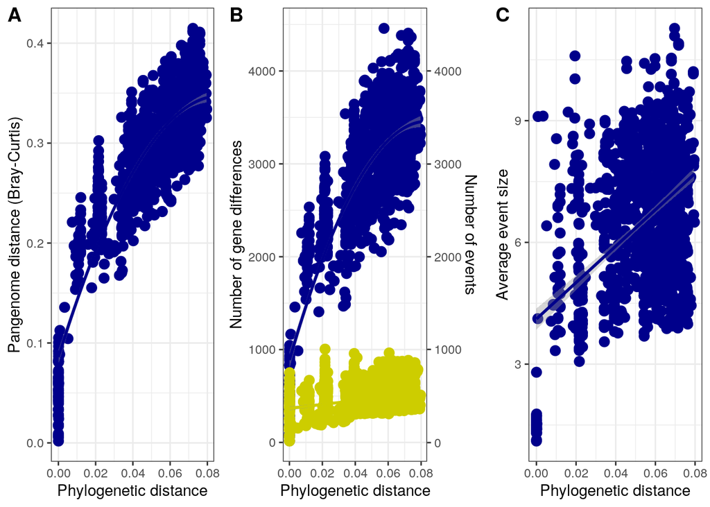

```r
function_plot_pangenome <- function(df){
  #visualize relationship between tree dist and pangenome distance, number of events, number of gene differences, and mean island size
#A) Pangenome dist
(pangenome_bray = ggplot(df,aes(x=tree_dist,y=dist_bray)) +
  geom_point(color='blue4',size=3) +
  theme_bw() +
  stat_smooth(data = df, method = "lm", color = 'blue4',formula = y ~ x + I(x^2), size = 1) +
  ylab('Pangenome distance (Bray-Curtis)') +
  xlab('Phylogenetic distance'))

#B) Events
(events = ggplot(df,aes(x=tree_dist)) +
  geom_point(aes(y=n_gene_diff_bray),color='blue4',size=3) +
  stat_smooth(aes(y=n_gene_diff_bray),
      method = "lm", color = 'blue4',formula = y ~ I(x^2) + x, size = 1) +
  geom_point(aes(y=n_events_bray),color='yellow3',size=3)   +
  stat_smooth(aes(y=n_events_bray),
      method = "lm", color = 'yellow3',formula =  y ~ x, size = 1) +
  theme_bw() +
  scale_y_continuous(
  name = "Number of gene differences",
  sec.axis = sec_axis( trans=~., name="Number of events")
  ) +
  xlab('Phylogenetic distance'))

## C) island size
(island_size = ggplot(df,aes(x=tree_dist,y=mean_size_events_bray)) +
  geom_point(color='blue4',size=3) +
  stat_smooth(method = "lm", color = 'blue4',formula = y ~ x, size = 1) +
  theme_bw() +
  ylab('Average event size') +
  xlab('Phylogenetic distance')
  )
fig = plot_grid(pangenome_bray,events,island_size,nrow=1,labels=c("A","B","C"),rel_widths = c(1,1.2,1))
return(fig)
}

(Bxy_plot = function_plot_pangenome(Bxy))
```

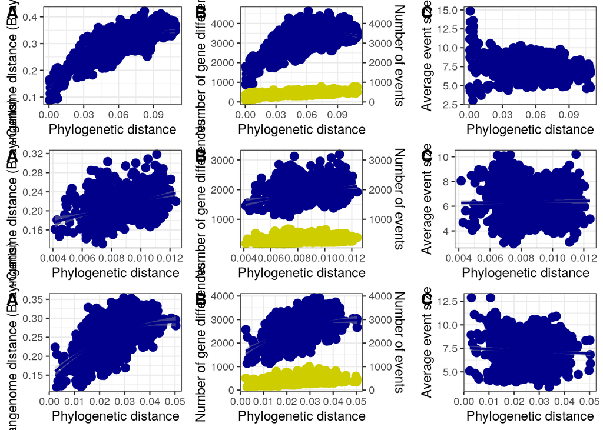

```r
ggsave(Bxy_plot,file=file.path(outdir,'Figure4_gene_content_evolution.pdf'),width=12,height=4)
Bov_plot = function_plot_pangenome(Bov)
Bfr_plot = function_plot_pangenome(Bfr)
Bth_plot = function_plot_pangenome(Bth)
(Bt_other = plot_grid(Bov_plot,Bfr_plot,Bth_plot,ncol=1))
```

```r
ggsave(Bt_other,file=file.path(outdir,'FigureS2_gene_content_evolution.pdf'),height=15,width=10)
df = Bxy
value='dist_bray'
run_mantel_tests <- function(df,value) {
  #run mantel test between tree distance and given variable
  tree_dist_M = df %>% select(iso1,iso2,tree_dist) %>%
    pivot_wider(names_from=iso2,values_from=tree_dist) %>%
    column_to_rownames('iso1') %>% as.matrix()
  value_dist_M = df %>% select(iso1,iso2,!!value) %>%
    pivot_wider(names_from=iso2,values_from=!!value) %>%
    column_to_rownames('iso1') %>% as.matrix()
  mantel.res = mantel(tree_dist_M, value_dist_M, method = "spearman", permutations = 9999, na.rm = TRUE)
  return(mantel.res)

}


run_mantel_test = function(df,species_name) {
  df_mantel = as.data.frame(rbind(
      run_mantel_tests(df,value='dist_bray'),
      run_mantel_tests(df,value='n_gene_diff_bray'),
      run_mantel_tests(df,value='n_events_bray'),
      run_mantel_tests(df,value='mean_size_events_bray')))
  df_mantel = df_mantel %>%
    mutate(name=value,
           species=species_name,
           statistic=round(as.numeric(statistic),3)) %>%
    select(species,name,method,permutations,statistic,signif) %>%
    dplyr::rename('pval'='signif')
  df_mantel$pval_fdr_adj = p.adjust(df_mantel$pval, method = 'fdr')
  return(df_mantel)
}

#Bacteroides_xylanisolvens
(Bxy_mantel = run_mantel_test(Bxy,'Bacteroides_xylanisolvens'))
```

```
##                     species      name                          method
## 1 Bacteroides_xylanisolvens dist_bray Spearman's rank correlation rho
## 2 Bacteroides_xylanisolvens dist_bray Spearman's rank correlation rho
## 3 Bacteroides_xylanisolvens dist_bray Spearman's rank correlation rho
## 4 Bacteroides_xylanisolvens dist_bray Spearman's rank correlation rho
##   permutations statistic  pval pval_fdr_adj
## 1         9999     0.755 1e-04        1e-04
## 2         9999     0.665 1e-04        1e-04
## 3         9999     0.283 1e-04        1e-04
## 4         9999     0.255 1e-04        1e-04
```

```r
#BBacteroides_ovatus
(Bov_mantel = run_mantel_test(Bov,'Bacteroides_ovatus'))
```

```
##              species      name                          method permutations
## 1 Bacteroides_ovatus dist_bray Spearman's rank correlation rho         9999
## 2 Bacteroides_ovatus dist_bray Spearman's rank correlation rho         9999
## 3 Bacteroides_ovatus dist_bray Spearman's rank correlation rho         9999
## 4 Bacteroides_ovatus dist_bray Spearman's rank correlation rho         9999
##   statistic   pval pval_fdr_adj
## 1     0.684  1e-04 0.0001333333
## 2     0.523  1e-04 0.0001333333
## 3     0.591  1e-04 0.0001333333
## 4    -0.209 0.9983 0.9983000000
```

```r
#Bacteroides_thetaiotaomicron
(Bth_mantel = run_mantel_test(Bth,'Bacteroides_thetaiotaomicron'))
```

```
##                        species      name                          method
## 1 Bacteroides_thetaiotaomicron dist_bray Spearman's rank correlation rho
## 2 Bacteroides_thetaiotaomicron dist_bray Spearman's rank correlation rho
## 3 Bacteroides_thetaiotaomicron dist_bray Spearman's rank correlation rho
## 4 Bacteroides_thetaiotaomicron dist_bray Spearman's rank correlation rho
##   permutations statistic   pval pval_fdr_adj
## 1         9999     0.469  1e-04 0.0001333333
## 2         9999     0.397  1e-04 0.0001333333
## 3         9999     0.342  1e-04 0.0001333333
## 4         9999    -0.049 0.7989 0.7989000000
```

```r
#Bacteroides_fragilis
(Bfr_mantel = run_mantel_test(Bfr,'Bacteroides_fragilis'))
```

```
##                species      name                          method permutations
## 1 Bacteroides_fragilis dist_bray Spearman's rank correlation rho         9999
## 2 Bacteroides_fragilis dist_bray Spearman's rank correlation rho         9999
## 3 Bacteroides_fragilis dist_bray Spearman's rank correlation rho         9999
## 4 Bacteroides_fragilis dist_bray Spearman's rank correlation rho         9999
##   statistic   pval pval_fdr_adj
## 1     0.419  1e-04 0.0002000000
## 2     0.356  1e-04 0.0002000000
## 3     0.252  7e-04 0.0009333333
## 4     0.009 0.4725 0.4725000000
```